# Virtually No Tag Autoencoder Documentation

## Introduction

This notebook is the development and documentation location for the abstract neural network to be used as an autoencoder for the Virtually No Tag project. That is, all code used to train the autoencoder will be in this document. The neural network will be exported for use elsewhere after having been trained here.

## General Idea

The general idea with this is to have an autoencoder form a compact, database-storable representation of a picture of a license plate. This way, these N-dimensional vector representations can be stored and used to determine (via euclidean distance) if two pictures are of the same license plate.

## Code

### Imports

```python
from keras.layers import Conv2D
from keras.layers import MaxPooling2D
from keras.layers import UpSampling2D
from keras.layers import Flatten
from keras.layers import Dense
from keras.layers import Input
from keras.layers import Reshape

from keras.models import Model

from keras.utils import to_categorical

from os import listdir
import cv2
import numpy as np
import matplotlib.pyplot as plt
```

### Data Loading

```
Loading all JPEG images from disk...
Finished 300 loading!
Alright, so 300 images are loaded and the result has shape (300, 96, 192, 3)
Example, showing first image:
```

[figure not shown]

```python
input_width = 192
input_height = 96
input_channels = 3

# Alright, so we want to get out data into the shape of (num images, height, width, 3)
def loadAllJPEGImages(path):
    print("Loading all JPEG images from disk...")
    imageList = sorted(listdir(path))
    loadedImages = [[]]
    for imageName in imageList:
        if (not (imageName.endswith(".jpg") or imageName.endswith(".jpeg"))):
            continue
        image = cv2.imread(path + imageName)
        image = cv2.cvtColor(image, cv2.COLOR_BGR2RGB)
        image = image.astype('float32') / 255.0
        loadedImages[0].append(np.asarray(image))
    print("Finished " + str(len(loadedImages[0])) + " loading!")
    output = np.concatenate(loadedImages, axis=0)
    return output

allImageData = loadAllJPEGImages("./plates/")
print("Alright, so " + str(len(allImageData)) + " images are loaded and the result has shape " + str(allImageData.shape))
print("Example, showing first image:")
plt.imshow(allImageData[0])
```

### Model

The model to be used for this autoencoder will be relatively simple. It will consist of 192*96 sized input, since a standard plate is 12 inches by 6 inches, and thus has a 2:1 width-height ratio. This size was chosen by visual inspection, as it appears to allow sufficient quality to distinguish between all characters on the plate (Q vs O or 0, B vs 8, etc) and is otherwise relatively small (for faster training and usage of the network). Also, it is divisible by 2^4, or can be divided by 2 (downsampled in maxpooling) evenly 4 times.

We will start with the encoder portion, listed below:

```python
input_layer = Input(shape=(input_height, input_width, input_channels))
```

```python
conv_layer_1 = Conv2D(32, (5,5), activation='relu', padding='same')(input_layer)
```

```python
max_pool_layer_1 = MaxPooling2D((2, 2), padding='same')(conv_layer_1)
```

```python
conv_layer_2 = Conv2D(32, (3, 3), activation='relu', padding='same')(max_pool_layer_1)
```

```python
max_pool_layer_2 = MaxPooling2D((2,2), padding='same')(conv_layer_2)
```

```python
conv_layer_3 = Conv2D(16, (3,3), activation='relu', padding='same')(max_pool_layer_2)
```

```python
max_pool_layer_3 = MaxPooling2D((2,2), padding='same')(conv_layer_3)
```

```python
conv_layer_4 = Conv2D(8, (3,3), activation='relu', padding='same')(max_pool_layer_3)
```

```python
max_pool_layer_4 = MaxPooling2D((2,2), padding='same')(conv_layer_4)
```

```python
encoded_layer = Conv2D(3, (3, 3), activation='relu', padding='same')(max_pool_layer_4)
```

Now, for the decoding portion:

```python
decode_conv_layer_1 = Conv2D(8, (3,3), activation='relu', padding='same')(encoded_layer)
```

```python
decode_upsampling_1 = UpSampling2D((2, 2))(decode_conv_layer_1)
```

```python
decode_conv_layer_2 = Conv2D(16, (3,3), activation='relu', padding='same')(decode_upsampling_1)
```

```python
decode_upsampling_2 = UpSampling2D((2,2))(decode_conv_layer_2)
```

```python
decode_conv_layer_3 = Conv2D(32, (3,3), activation='relu', padding='same')(decode_upsampling_2)
```

```python
decode_upsampling_3 = UpSampling2D((2,2))(decode_conv_layer_3)
```

```python
decode_conv_layer_4 = Conv2D(32, (5,5), activation='relu', padding='same')(decode_upsampling_3)
```

```python
decode_upsampling_4 = UpSampling2D((2,2))(decode_conv_layer_4)
```

```python
decoded_layer = Conv2D(3, (3,3), activation='relu', padding='same')(decode_upsampling_4)
```

```python
autoencoder = Model(input_layer, decoded_layer)
```

Now we print a summary of our created autoencoder and compile the model:

```python
print(autoencoder.summary())
```

```
_________________________________________________________________
Layer (type)                 Output Shape              Param #
=================================================================
input_1 (InputLayer)         (None, 96, 192, 3)        0
_________________________________________________________________
conv2d_1 (Conv2D)            (None, 96, 192, 32)       2432
_________________________________________________________________
max_pooling2d_1 (MaxPooling2 (None, 48, 96, 32)        0
_________________________________________________________________
conv2d_2 (Conv2D)            (None, 48, 96, 32)        9248
_________________________________________________________________
max_pooling2d_2 (MaxPooling2 (None, 24, 48, 32)        0
_________________________________________________________________
conv2d_3 (Conv2D)            (None, 24, 48, 16)        4624
_________________________________________________________________
max_pooling2d_3 (MaxPooling2 (None, 12, 24, 16)        0
_________________________________________________________________
conv2d_4 (Conv2D)            (None, 12, 24, 8)         1160
_________________________________________________________________
max_pooling2d_4 (MaxPooling2 (None, 6, 12, 8)          0
_________________________________________________________________
conv2d_5 (Conv2D)            (None, 6, 12, 3)          219
_________________________________________________________________
conv2d_6 (Conv2D)            (None, 6, 12, 8)          224
_________________________________________________________________
up_sampling2d_1 (UpSampling2 (None, 12, 24, 8)         0
_________________________________________________________________
conv2d_7 (Conv2D)            (None, 12, 24, 16)        1168
_________________________________________________________________
up_sampling2d_2 (UpSampling2 (None, 24, 48, 16)        0
_________________________________________________________________
conv2d_8 (Conv2D)            (None, 24, 48, 32)        4640
_________________________________________________________________
up_sampling2d_3 (UpSampling2 (None, 48, 96, 32)        0
_________________________________________________________________
conv2d_9 (Conv2D)            (None, 48, 96, 32)        25632
_________________________________________________________________
up_sampling2d_4 (UpSampling2 (None, 96, 192, 32)       0
_________________________________________________________________
conv2d_10 (Conv2D)           (None, 96, 192, 3)        867
=================================================================
Total params: 50,214
Trainable params: 50,214
Non-trainable params: 0
_________________________________________________________________
None
```

```python
autoencoder.compile(optimizer='adam', loss='mean_squared_error')
```

### Training

Below we perform the training for the autoencoder using our set of plate images that are already correctly resized. 250 of the images are used for training, and 50 as validation data.

```python
autoencoder.fit(allImageData[0:250], allImageData[0:250], epochs=500, batch_size=50, shuffle=True, validation_data=(allImageData[250:300], allImageData[250:300]))
```

```
Train on 250 samples, validate on 50 samples
```

```
<keras.callbacks.History at 0x7f4208906198>
```

Now we can decode all images and save the model:

```python
# Decode everything!
decoded_imgs = autoencoder.predict(allImageData)

print(decoded_imgs.shape)
```

```
(300, 96, 192, 3)
```

```python
#Shall we save our model?
autoencoder.save("smallest_with_3_channel_extended_network.h5")
```

### Visualizing the Results

Below we will create a model of only the encoder portion of the network, and then we will present visually on 6 rows 6 separate images, their encoded forms, and their decoded forms. Also printed is various distance information showing that the distance between images of the same plate and images of two different plates is differing in general magnitude.

```python
# Get intermediate encoder-only model
encoderModel = Model(input_layer, encoded_layer)
```

```python
# Get encoded form of all images
encodedImages = encoderModel.predict(allImageData)
```

```
Clipping input data to the valid range for imshow with RGB data ([0..1] for floats or [0..255] for integers).
```

```
Distance between rows 1 and 2 = 1.2248330364410003
Distance between rows 1 and 3 = 5.151444642606076
Distance between rows 1 and 5 = 4.1228288924493475
Distance between rows 3 and 4 = 1.2666767514380297
Distance between rows 3 and 1 = 5.151444642606076
Distance between rows 3 and 5 = 2.482763995203561
Distance between rows 5 and 6 = 1.017430788464898
Distance between rows 5 and 1 = 4.1228288924493475
Distance between rows 5 and 3 = 2.482763995203561
```

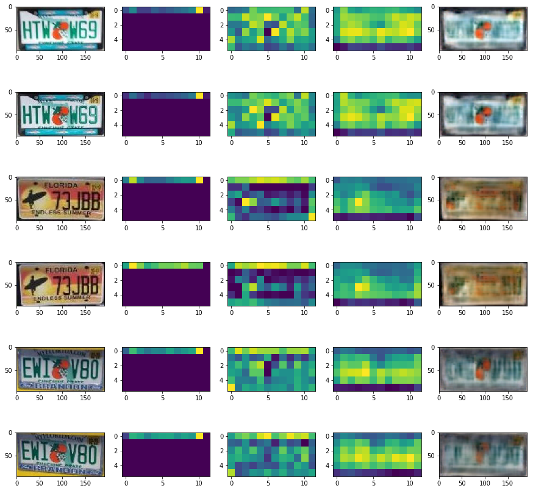

```python
# This method returns a distance metric between two encoded forms.
# Treats each channel as a 72-dimensional vector and computes
# euclidean distance between each channel. Then computes vector
# magnitude of the channel distances as the result.
def distances(encodedImages, index1, index2):
    channel0_1 = encodedImages[index1][:,:,0]
    channel1_1 = encodedImages[index1][:,:,1]
    channel2_1 = encodedImages[index1][:,:,2]

    channel0_2 = encodedImages[index2][:,:,0]
    channel1_2 = encodedImages[index2][:,:,1]
    channel2_2 = encodedImages[index2][:,:,2]

    channel0_mse = channel0_1 - channel0_2
    channel0_mse = channel0_mse * channel0_mse
    channel0_mse = np.sum(channel0_mse)
    channel0_mse = np.sqrt(channel0_mse)

    channel1_mse = channel1_1 - channel1_2
    channel1_mse = channel1_mse * channel1_mse
    channel1_mse = np.sum(channel1_mse)
    channel1_mse = np.sqrt(channel1_mse)

    channel2_mse = channel2_1 - channel2_2
    channel2_mse = channel2_mse * channel2_mse
    channel2_mse = np.sum(channel2_mse)
    channel2_mse = np.sqrt(channel2_mse)

    return np.sqrt(channel0_mse**2 + channel1_mse**2 + channel2_mse**2)

nrows = 6
ncols = 5
fig = plt.figure(figsize=(15,15))
fig.add_subplot(nrows, ncols, 1)
plt.imshow(allImageData[147])
fig.add_subplot(nrows, ncols, 2)
plt.imshow(encodedImages[147][:,:,0])
fig.add_subplot(nrows, ncols, 3)
plt.imshow(encodedImages[147][:,:,1])
fig.add_subplot(nrows, ncols, 4)
plt.imshow(encodedImages[147][:,:,2])
fig.add_subplot(nrows, ncols, 5)
plt.imshow(decoded_imgs[147])

fig.add_subplot(nrows, ncols, 6)
plt.imshow(allImageData[148])
fig.add_subplot(nrows, ncols, 7)
plt.imshow(encodedImages[148][:,:,0])
fig.add_subplot(nrows, ncols, 8)
plt.imshow(encodedImages[148][:,:,1])
fig.add_subplot(nrows, ncols, 9)
plt.imshow(encodedImages[148][:,:,2])
fig.add_subplot(nrows, ncols, 10)
plt.imshow(decoded_imgs[148])

print("Distance between rows 1 and 2 = " + str(distances(encodedImages, 147, 148)))
print("Distance between rows 1 and 3 = " + str(distances(encodedImages, 147, 201)))
print("Distance between rows 1 and 5 = " + str(distances(encodedImages, 147, 21)))

fig.add_subplot(nrows, ncols, 11)
plt.imshow(allImageData[201])
fig.add_subplot(nrows, ncols, 12)
plt.imshow(encodedImages[201][:,:,0])
fig.add_subplot(nrows, ncols, 13)
plt.imshow(encodedImages[201][:,:,1])
fig.add_subplot(nrows, ncols, 14)
plt.imshow(encodedImages[201][:,:,2])
fig.add_subplot(nrows, ncols, 15)
plt.imshow(decoded_imgs[201])

fig.add_subplot(nrows, ncols, 16)
plt.imshow(allImageData[202])
fig.add_subplot(nrows, ncols, 17)
plt.imshow(encodedImages[202][:,:,0])
fig.add_subplot(nrows, ncols, 18)
plt.imshow(encodedImages[202][:,:,1])
fig.add_subplot(nrows, ncols, 19)
plt.imshow(encodedImages[202][:,:,2])
fig.add_subplot(nrows, ncols, 20)
plt.imshow(decoded_imgs[202])


print("Distance between rows 3 and 4 = " + str(distances(encodedImages, 201, 202)))
print("Distance between rows 3 and 1 = " + str(distances(encodedImages, 201, 147)))
print("Distance between rows 3 and 5 = " + str(distances(encodedImages, 201, 21)))

fig.add_subplot(nrows, ncols, 21)
plt.imshow(allImageData[21])
fig.add_subplot(nrows, ncols, 22)
plt.imshow(encodedImages[21][:,:,0])
fig.add_subplot(nrows, ncols, 23)
plt.imshow(encodedImages[21][:,:,1])
fig.add_subplot(nrows, ncols, 24)
plt.imshow(encodedImages[21][:,:,2])
fig.add_subplot(nrows, ncols, 25)
plt.imshow(decoded_imgs[21])

fig.add_subplot(nrows, ncols, 26)
plt.imshow(allImageData[22])
fig.add_subplot(nrows, ncols, 27)
plt.imshow(encodedImages[22][:,:,0])
fig.add_subplot(nrows, ncols, 28)
plt.imshow(encodedImages[22][:,:,1])
fig.add_subplot(nrows, ncols, 29)
plt.imshow(encodedImages[22][:,:,2])
fig.add_subplot(nrows, ncols, 30)
plt.imshow(decoded_imgs[22])

print("Distance between rows 5 and 6 = " + str(distances(encodedImages, 21, 22)))
print("Distance between rows 5 and 1 = " + str(distances(encodedImages, 21, 147)))
print("Distance between rows 5 and 3 = " + str(distances(encodedImages, 21, 201)))

plt.show()
```

End of document.